# Semicon Simulation: Analysis Portion

Group 15

2023-04-22

## PRELIMINARY DATA WRANGLING IN MICROSOFT EXCEL

**Step 1:** The output data from our JaamSim Semicon Simulation containing 1.4k observations was converted from .txt file format to .xlsx file format using Microsoft Excel.

**Step 2:** The following Excel formulas were applied to all three Excel files containing data of three variations of the Simulation.

- *Case 1:* All 5 regions are involved in the system process.
- *Case 2:* China is cut off from the system process.
- *Case 3:* USA is cut off from the system process.

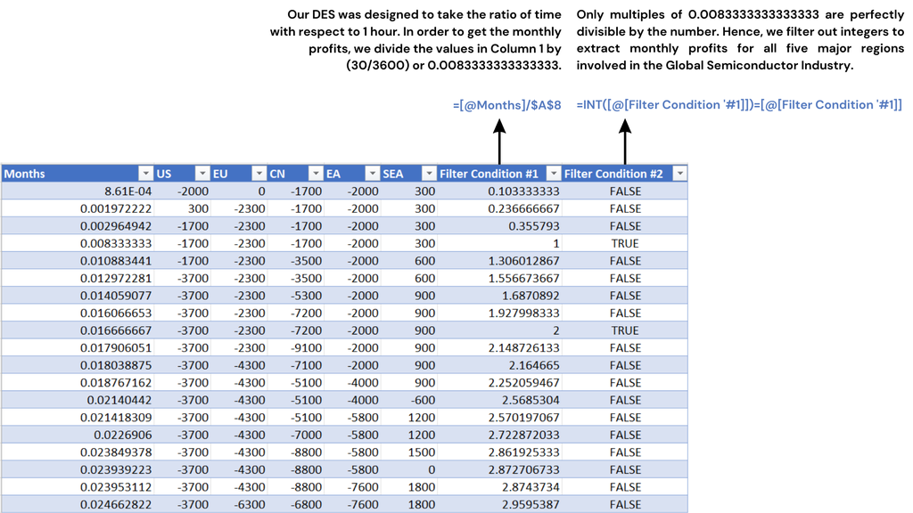

**Step 3:** All three Excel files are exported as .csv files for further data manipulation and statistical analysis in R.

## Loading the data sets:

```r
original <- read.csv('original.csv')
cut_china <- read.csv('cut_china.csv')
cut_us <- read.csv('cut_us.csv')
```

# DATA CLEANING & MANIPULATION

## Filtering data frames by “TRUE” condition:

```r
#install.packages("dplyr") -> for data manipulation
library(dplyr)
original <- filter(original, Filter.Condition..2 == 'TRUE')
cut_china <- filter(cut_china, Filter.Condition..2 == 'TRUE')
cut_us <- filter(cut_us, Filter.Condition..2 == 'TRUE')
```

## Deleting the “Months” & “Filter.Condition..2” columns:

```r
#install.packages("magrittr") -> to use the pipe operator (%>%)
library(magrittr)

original <- original %>% dplyr::select(-c(Months, Filter.Condition..2))
cut_china <- cut_china %>% dplyr::select(-c(Months, Filter.Condition..2))
cut_us <- cut_us %>% dplyr::select(-c(Months, Filter.Condition..2))
```

```r
names(original)[6] = "Months"
names(cut_china)[6] = "Months"
names(cut_us)[6] = "Months"
```

## Finding the average profit of the overall system for 3 unique cases:

```r
original$AVG_Original <- rowMeans(original[1:5], na.rm=TRUE)
cut_china$AVG_Cut_China <- rowMeans(cut_china[1:5], na.rm=TRUE)
cut_us$AVG_Cut_USA <- rowMeans(cut_us[1:5], na.rm=TRUE)
```

## Creating a new data frame with the essential data:

```r
df <- data.frame(
  Months = c(1:121),
  original$AVG_Original,
  cut_china$AVG_Cut_China,
  cut_us$AVG_Cut_USA)
```

## Renaming the columns:

```r
names(df)[2] = "AVG_Original"
names(df)[3] = "AVG_Cut_China"
names(df)[4] = "AVG_Cut_USA"
```

## Preserving top 120 data points:

We will perform the paired t-test on a data sample consisting of the first 120 months (10 years).

```r
df <- head(df, -1)
dim(df)
```

```
## [1] 120   4
```

Since the data used for analysis is generated from a terminating simulation with **“empty-and-idle”** initial conditions, it is important to ensure that the simulation is properly initialized to avoid making any incorrect statistical inferences.

The following line graphs perfectly illustrate the initial instabilities in the system processes:

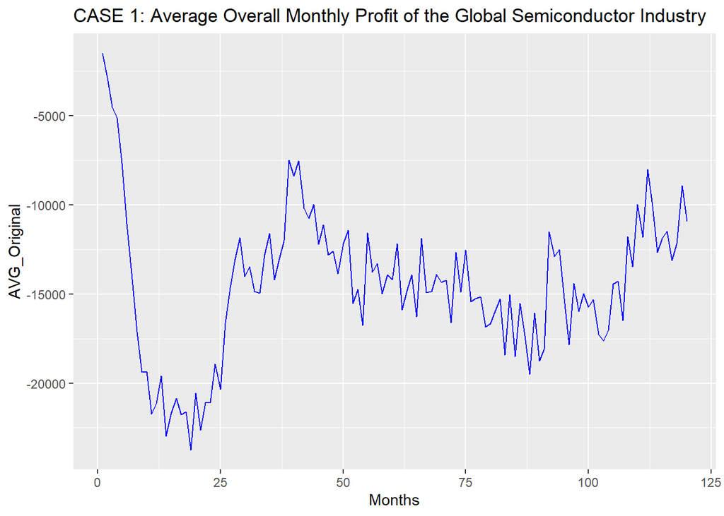

```r
#install.packages("ggplot2") -> for data visualizations
library(ggplot2)

ggplot(df, aes(x = Months, y = AVG_Original)) + geom_line(color="blue") + ggtitle("CASE 1: Average Overall Monthly Profit of the Global Semiconductor Industry")
```

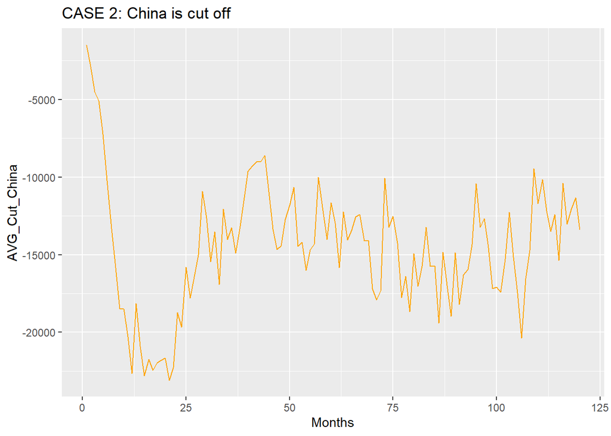

```r
ggplot(df, aes(x = Months, y = AVG_Cut_China)) + geom_line(color="orange") + ggtitle("CASE 2: China is cut off")
```

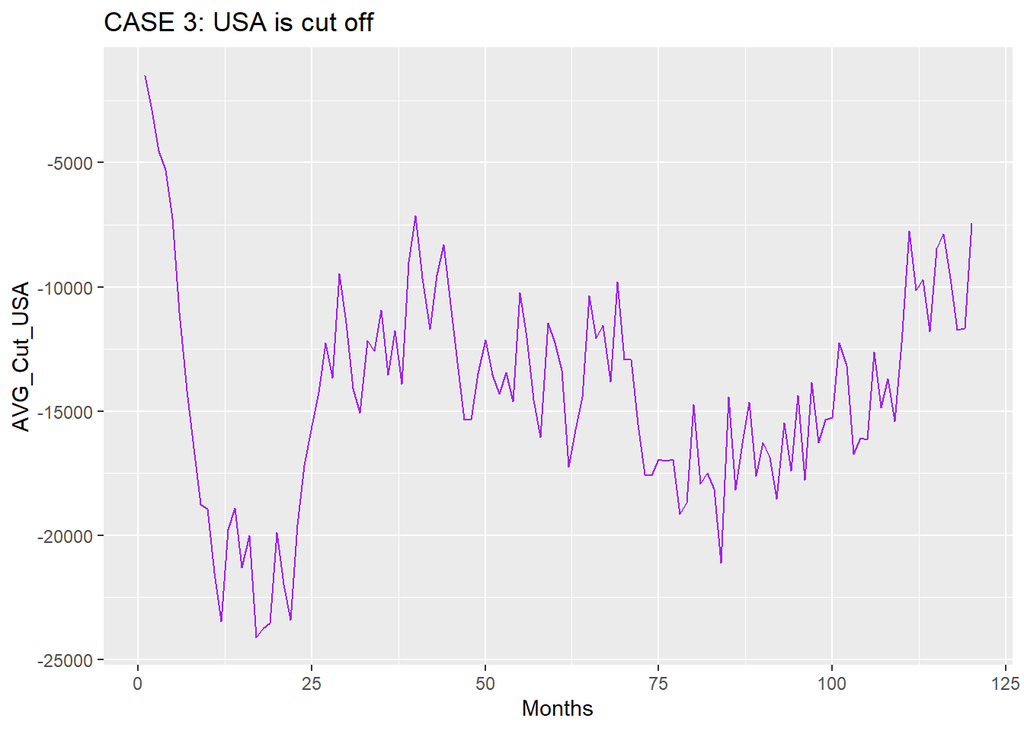

```r
ggplot(df, aes(x = Months, y = AVG_Cut_USA)) + geom_line(color="purple") + ggtitle("CASE 3: USA is cut off")
```

However, since the data generated is not from a steady-state simulation, we cannot truncate data points using the **Welch’s Method**.

The first few observations containing NULL profit values were removed in Microsoft Excel as an attempt to solve biases related to the “empty-and-idle” initial data values.

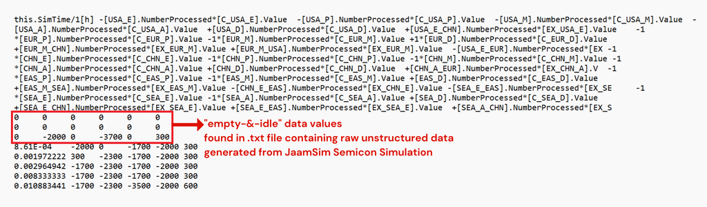

## Here is the final data frame!

```r
head(df)
```

```
##   Months AVG_Original AVG_Cut_China AVG_Cut_USA
## 1      1        -1480         -1480       -1480
## 2      2        -2860         -2860       -2860
## 3      3        -4520         -4520       -4520
## 4      4        -5100         -5100       -5300
## 5      5        -7640         -7240       -7240
## 6      6       -11060        -10220      -11040
```

# DATA EXPLORATION

The following box plots are used to visualize the spread of the Average Overall Profits for the three cases over the course of 10 years:

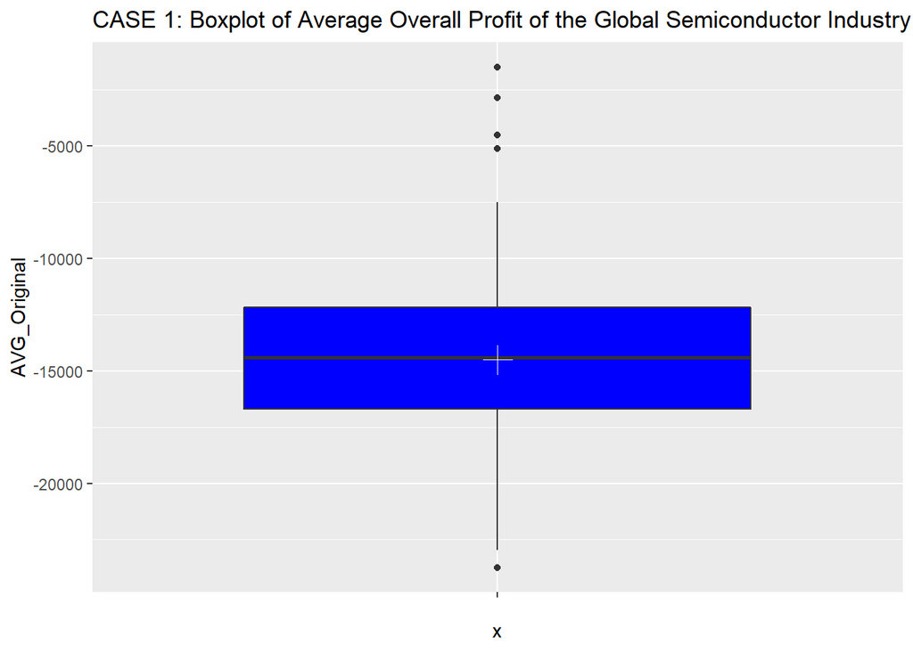

```r
ggplot(df) + aes(x = "", y = AVG_Original) + geom_boxplot(fill = "blue") + ggtitle("CASE 1: Boxplot of Average Overall Profit of the Global Semiconductor Industry") + stat_summary(fun.y = "mean", geom = "point", size = 5, color = "white", shape = 3)
```

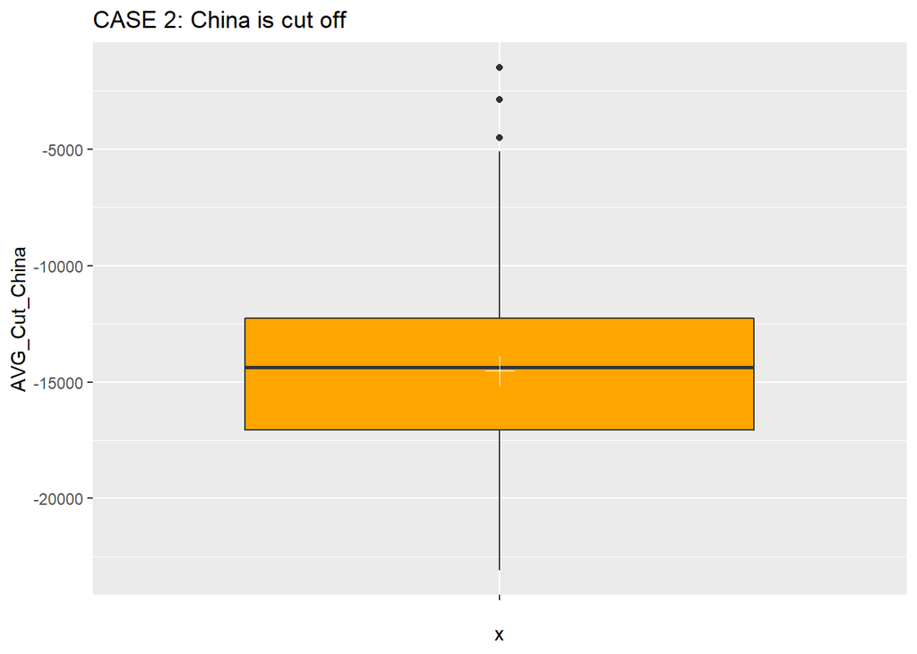

```r
ggplot(df) + aes(x = "", y = AVG_Cut_China) + geom_boxplot(fill = "orange") + ggtitle("CASE 2: China is cut off") + stat_summary(fun.y = "mean", geom = "point", size = 5, color = "white", shape = 3)
```

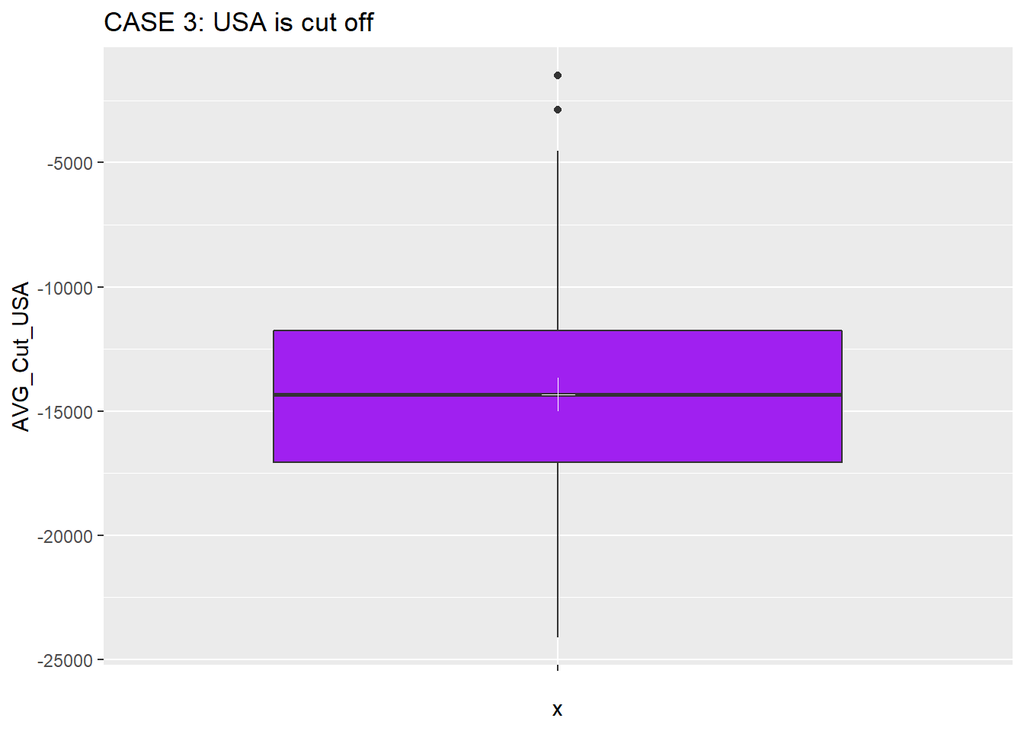

```r
ggplot(df) + aes(x = "", y = AVG_Cut_USA) + geom_boxplot(fill = "purple") + ggtitle("CASE 3: USA is cut off") + stat_summary(fun.y = "mean", geom = "point", size = 5, color = "white", shape = 3)
```

The box plots has revealed **10 outliers** which must be removed from the data set.

```r
boxplot(df$AVG_Original, plot = FALSE)$out
```

```
## [1]  -1480  -2860  -4520  -5100 -23740
```

```r
boxplot(df$AVG_Cut_China, plot = FALSE)$out
```

```
## [1] -1480 -2860 -4520
```

```r
boxplot(df$AVG_Cut_USA, plot = FALSE)$out
```

```
## [1] -1480 -2860
```

## Procedure for removing outliers & replacing those data entries with NULL values:

```r
for (x in c('AVG_Original','AVG_Cut_China', 'AVG_Cut_USA'))
{
  value = df[,x][df[,x] %in% boxplot.stats(df[,x])$out]
  df[,x][df[,x] %in% value] = NA
}
```

## Mean of the Average Overall Profits for all three cases:

```r
colMeans(df[,2:4], na.rm = TRUE)
```

```
##  AVG_Original AVG_Cut_China   AVG_Cut_USA
##     -14803.30     -14824.44     -14527.46
```

# STATISTICAL TESTS

In order to evaluate if cutting off China or USA has any impact on the overall economy of the global semiconductor industry, we perform the **paired t-test**. This statistical procedure determines if the mean differences of the paired cases are statistically significant.

The average monthly profit of all five regions is used as the **performance measure** to compare the systems.

## Paired t-test Assumptions:

Before proceeding with the paired t-test, we must also check if the differences between the pairs are approximately normally distributed.

## Checking for the Assumption of Normality using the Q-Q Plot:

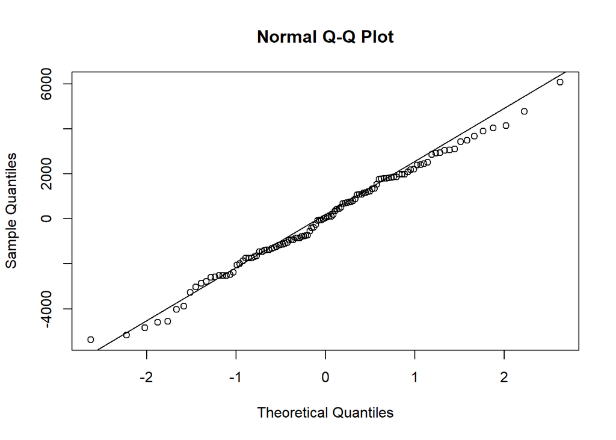

```r
#install.packages("stats") -> to perform statistical calculations and tests
library(stats)

difference_OGxCN <- df$AVG_Original - df$AVG_Cut_China
qqnorm(difference_OGxCN)
qqline(difference_OGxCN, datax = FALSE, distribution = qnorm, probs = c(0.25, 0.75))
```

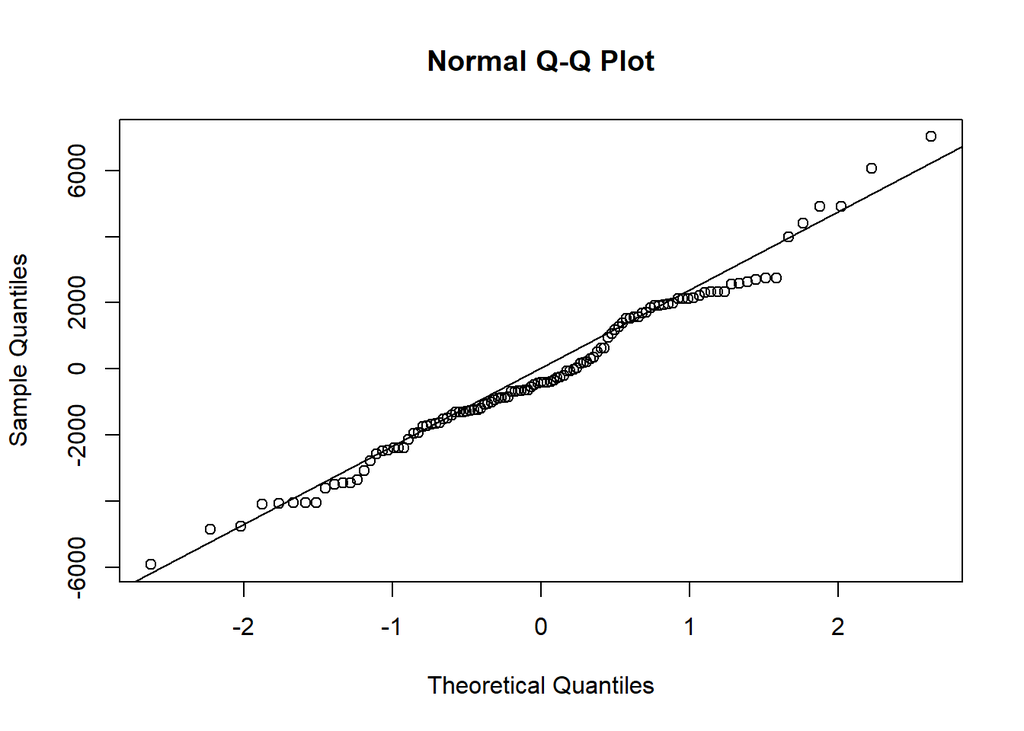

```r
difference_OGxUS <- df$AVG_Original - df$AVG_Cut_USA
qqnorm(difference_OGxUS)
qqline(difference_OGxUS, datax = FALSE, distribution = qnorm, probs = c(0.25, 0.75))
```

Since the data points lie closely to the line for both pairs, the assumption of normality has been met!

## HYPOTHESIS TESTING: Paired t-test for Comparing Systems

```r
t_test_for_case_1 <- t.test(df$AVG_Original, df$AVG_Cut_China, paired = TRUE, data = df)
t_test_for_case_1
```

```
##
##  Paired t-test
##
## data:  df$AVG_Original and df$AVG_Cut_China
## t = 0.21341, df = 114, p-value = 0.8314
## alternative hypothesis: true mean difference is not equal to 0
## 95 percent confidence interval:
##  -373.0796  463.1666
## sample estimates:
## mean difference
##        45.04348
```

```r
t_test_for_case_2 <- t.test(df$AVG_Original, df$AVG_Cut_USA, paired = TRUE, data = df)
t_test_for_case_2
```

```
##
##  Paired t-test
##
## data:  df$AVG_Original and df$AVG_Cut_USA
## t = -0.85011, df = 114, p-value = 0.397
## alternative hypothesis: true mean difference is not equal to 0
## 95 percent confidence interval:
##  -622.0403  248.4751
## sample estimates:
## mean difference
##       -186.7826
```

Since our p-values for both cases are greater than the significance level of 0.05, we fail to reject the null hypothesis which states that the true mean difference is equal to 0 for both cases.

*In other words, neither cutting off China nor cutting off USA has any statistically significant impact on the overall profit of the global semiconductor industry.*

*Therefore, we can infer that the overall economy of the global semiconductor industry is resilient over a decade despite cutting off China & USA from the system.*

## Limitations:

- More research on ways to properly initialize data generated from terminating simulations could have been performed for its implementation in R.

From the line graphs above, we detect “initialization bias” until the first 2 years (24 months). However, reproducing the paired t-test to compare systems still gives the same test results as before.

**p-value >>> significance level**

## HYPOTHESIS TESTING: Paired t-test after removing the first 2 years data

```r
new_df <- df[25:120, ]

t_test_for_case_1 <- t.test(new_df$AVG_Original, new_df$AVG_Cut_China, paired = TRUE, data = new_df)
t_test_for_case_1
```

```
##
##  Paired t-test
##
## data:  new_df$AVG_Original and new_df$AVG_Cut_China
## t = 0.40665, df = 95, p-value = 0.6852
## alternative hypothesis: true mean difference is not equal to 0
## 95 percent confidence interval:
##  -389.8150  590.6483
## sample estimates:
## mean difference
##        100.4167
```

```r
t_test_for_case_2 <- t.test(new_df$AVG_Original, new_df$AVG_Cut_USA, paired = TRUE, data = new_df)
t_test_for_case_2
```

```
##
##  Paired t-test
##
## data:  new_df$AVG_Original and new_df$AVG_Cut_USA
## t = -0.75831, df = 95, p-value = 0.4501
## alternative hypothesis: true mean difference is not equal to 0
## 95 percent confidence interval:
##  -696.4612  311.4612
## sample estimates:
## mean difference
##          -192.5
```

- Averaging the monthly profits might not be the most robust performance measure to assess the overall performance of the global semiconductor industry.

## Appendix:

Another interesting use case of the Semicon Simulation would be to look to the impact of the removal of China & USA on the monthly profits of individual countries. This can be visualized using box plots!